# Brain Stroke Prediction - Homework 5

## Introduction

I'm going to explore brain stroke factors and their relevance using Permutation-based Variable Importance.

## Part 1

[interactive chart not shown]

By far the most important feature is `age`. `bmi` is second most important with meaningful contribution. The rest of features seem to have small importance.

## Part 2

[interactive chart not shown]

The original model (xgb with sample weighting, 200 estimators and 6 max tree depth) was compared to:

- same model, but without sample weighting
- same model, but with 33 estimators and 4 max depth
- logistic regression model

In all models, by far the most important feature is age.

In case of logistic regression we observe higher importance of one-hot encoded features. It might be the case where in general some feature is not important, but it is only important in case this feature takes certain value.

## Part 3

| variable | dropout_loss | gini | shap |
| --- | --- | --- | --- |
| gender | -0.018460 | 0.086934 | 0.001648 |
| smoking_status | -0.017236 | 0.091549 | 0.005219 |
| hypertension | -0.009518 | 0.087021 | 0.001075 |
| Residence_type | -0.006622 | 0.040552 | 0.002003 |
| work_type | -0.004868 | 0.084537 | 0.002718 |
| avg_glucose_level | -0.000174 | 0.079506 | 0.010447 |
| heart_disease | 0.001608 | 0.098870 | 0.000982 |
| ever_married | 0.003800 | 0.074906 | 0.000884 |
| bmi | 0.048319 | 0.081631 | 0.009660 |
| age | 0.225658 | 0.274494 | 0.031507 |

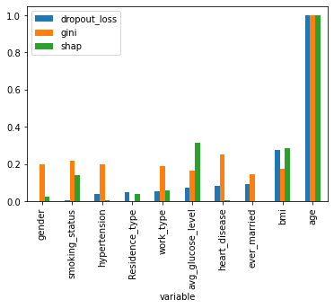

Table above contains 3 columns - `dropout loss` - importance calculated using PVI, `gini` - gini impurity measure built in xgboost and `shap` calculated using TreeShap from `shap` library.

If one gets dizzy looking at tabular data, below is a plot of data in table, normalized on a column basis.

Using all 3 methods, `age` is the most important feature for our model.

In case of `gini`, almost all features matter. It's not the case for other methods.

For PVI bmi is also an important feature. Other than age and bmi features don't matter too much.

For `shap` second and third most important features are `bmi` and `avg_glucose_level`, they seem to have similar importance.